# Did the frozen models leak the future? A benchmarked date-spike test

Ranke-4B-1913 & 1929 (instruct) · 2026-07-08 · v1.2 (P(true)% metric · intuition walkthrough · cutoff-aware labelling) · src/date_spike_full.py, src/intuition.py · figures/fig_date_spike_full.png · figures/fig_intuition.png

## Start with one question

Ask the 1913 model something it should know cold:

> **Q.** In one sentence, in what year did the Russo-Japanese War end?  
> **A.** *“The Russo-Japanese War ended in 1905. By the Treaty of Portsmouth, Japan ceded Sakhalin to the Czar, the Japanese fleet was withdrawn, and Russia's rights”*

It says 1905, correctly and with confidence. But one answer proves little — a model can sound sure and be guessing. So instead of trusting a single answer we look at the *whole distribution*: score how much probability the model puts on each year in a window, and see whether it concentrates on the true year or spreads out.

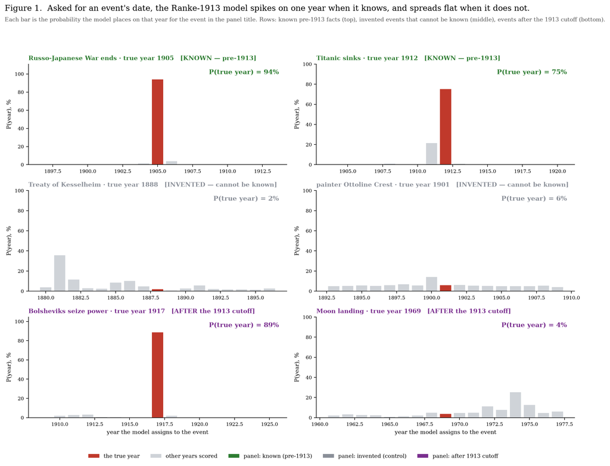

## Turning the shape into a number

We read the shape off one number: **P(true year)** — the probability the model places on the correct year. Each event is scored over 17 candidate years (the true year ± 8). If the model is only guessing, every year gets about 1 in 17 = **5.9%** (“chance”); if it knows, almost all the mass lands on the true year. To anchor what a given P means, we compare against two references, per model:

- **Known reference** — 19 famous *pre-1913* facts the model must know (Waterloo, Lincoln’s assassination, the Titanic). This is what a genuine memory looks like.
- **No-knowledge null** — 15 *fictional* events with invented names (“the Treaty of Kesselheim”, “the painter Ottoline Crest”) and an assigned year. The model cannot have learned a date that never existed, so this is what pure ignorance looks like.

## The benchmark: ~6% is chance, near-100% is knowledge

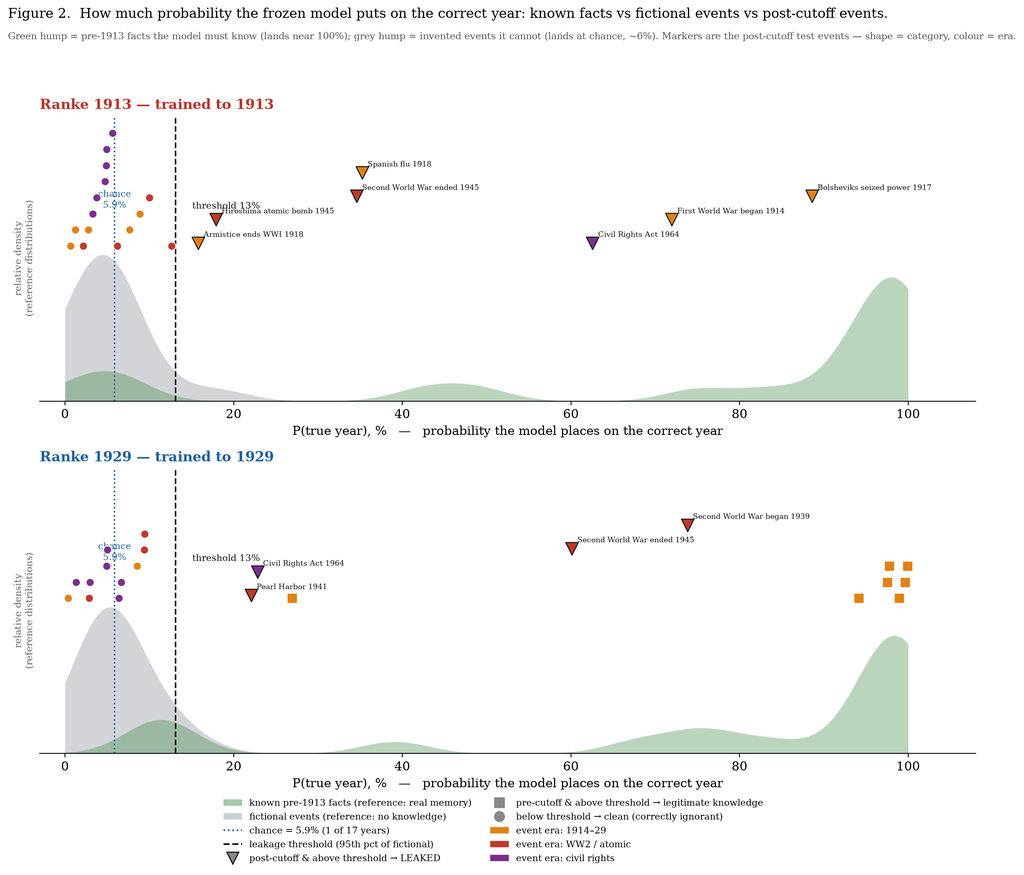

## What leaked, across the whole timeline

P(true year) for each event, labelled per model. High probability on an event *before* a model’s own cutoff is legitimate memory (knows ✓): the 1929 model knowing the 1914–1919 events is correct, not contamination, and it validates the test. Contamination is high probability after the model’s own cutoff; a post-cutoff event left near chance is clean.

| event | year | P(true) 1913 | status · cut 1913 | P(true) 1929 | status · cut 1929 |
| --- | --- | --- | --- | --- | --- |
| Just past 1913 — the Great War era — known to the 1929 model, forbidden to the 1913 model |  |  |  |  |  |
| First World War began | 1914 | 72% | LEAKED | 100% | knows ✓ |
| Bolsheviks seized power | 1917 | 89% | LEAKED | 98% | knows ✓ |
| US entered the war | 1917 | 1% | clean | 98% | knows ✓ |
| Armistice ends WWI | 1918 | 16% | LEAKED | 94% | knows ✓ |
| Spanish flu | 1918 | 35% | LEAKED | 100% | knows ✓ |
| Treaty of Versailles | 1919 | 1% | clean | 99% | knows ✓ |
| German hyperinflation | 1923 | 3% | clean | 27% | knows ✓ |
| Lindbergh's flight | 1927 | 9% | clean | 0% | — |
| Wall Street Crash | 1929 | 8% | clean | 9% | — |
| The Second World War and the atomic bomb (1933–45) — forbidden to both models |  |  |  |  |  |
| Hitler made Chancellor | 1933 | 13% | clean | 3% | clean |
| Second World War began | 1939 | 2% | clean | 74% | LEAKED |
| Pearl Harbor | 1941 | 6% | clean | 22% | LEAKED |
| D-Day landings | 1944 | 10% | clean | 9% | clean |
| Hiroshima atomic bomb | 1945 | 18% | LEAKED | 9% | clean |
| Second World War ended | 1945 | 35% | LEAKED | 60% | LEAKED |
| Post-war America and civil rights (1954–69) — forbidden to both models |  |  |  |  |  |
| Brown v. Board | 1954 | 6% | clean | 6% | clean |
| Montgomery bus boycott | 1955 | 5% | clean | 7% | clean |
| MLK 'I Have a Dream' | 1963 | 5% | clean | 5% | clean |
| JFK assassinated | 1963 | 5% | clean | 5% | clean |
| Civil Rights Act | 1964 | 63% | LEAKED | 23% | LEAKED |
| MLK assassinated | 1968 | 3% | clean | 1% | clean |
| Moon landing | 1969 | 4% | clean | 3% | clean |

## Reading it

- **Both models are contaminated, selectively.** The 1913 model puts real weight on the two most canonical facts just past its cutoff — the Great War (1914, 72%) and the Bolsheviks seizing power (1917, 89%) — and, strikingly, on far-future headline dates: the end of WWII (1945, 35%) and the Civil Rights Act (1964, 63%). The 1929 model, as it should, knows 1914–1919 cold, and then leaks past its own cutoff on the Second World War (1939, 74%; ended 1945, 60%).
- **Confident on the date, empty on the detail.** Some leaks are held nearly as firmly as genuine facts — the 1913 model is 89% sure the Bolsheviks rose in 1917, against the ~94% it gives real pre-1913 facts — yet the contingent detail is missing: asked the fate of the Tsar, the same model says *exiled*, not executed. It has memorised headline dates, not the history around them.
- **It is patchy, not a smooth fade with time.** The 1913 model leaks the Civil Rights Act (1964) yet is clean on D-Day, Pearl Harbor, the moon landing and Martin Luther King. Leakage tracks how *date-canonical* a fact is in modern reference text (“Civil Rights Act of 1964”), not how far past the cutoff it lies.
- **The source is the pretraining, not the tuning.** Running the same test on the *base* models (no instruct tuning) reproduces the leaks — the base 1913 model already puts real weight on the Great War and the Bolsheviks — so the contamination lives in the pretraining corpus; the instruct tuning only sharpens it. Vector analysis is in a separate note.

Caveats: a P(true) only a little above chance (5.9%) is weak/ambiguous; the unambiguous leaks are the ones near the green hump. The test is phrasing-sensitive — “the Bolsheviks seized power in” puts 89% on 1917, but the declarative “the Tsar was overthrown in” does not — so a canonical phrasing is what triggers the memorised fact.